# Data Visualization - Case Study 1 to 4

# CLASS PRACTICE 2

1. Plot the following using ggplot()

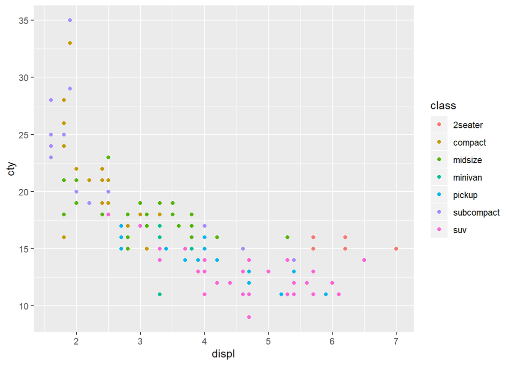

```r
ggplot(mpg, aes(x=displ, y = cty, colour = class)) +
  geom_point()
```

2. Plot the following (adding one more dimension):

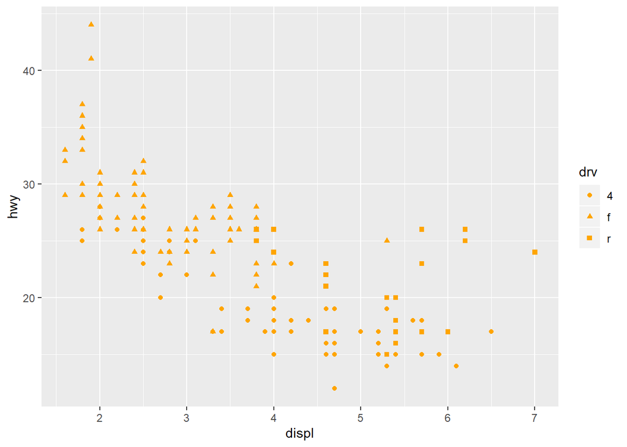

```r
ggplot(mpg, aes(x=displ, y = hwy, shape = drv)) +
    geom_point(colour = "orange")
```

3. Plot the following graph (adding more dimensions)

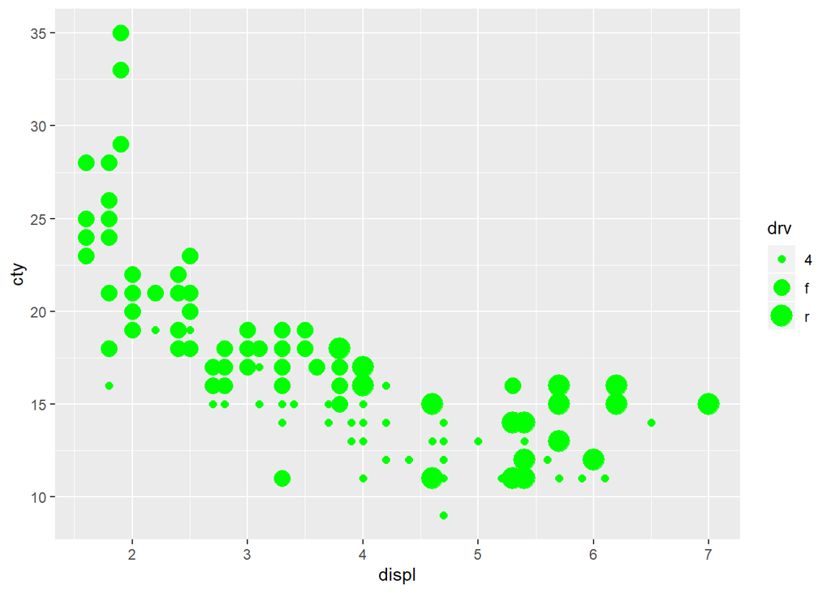

```r
ggplot(mpg, aes(x=displ, y = cty, size = drv)) +
 geom_point(colour="green")
```

4. Plot the following graph:

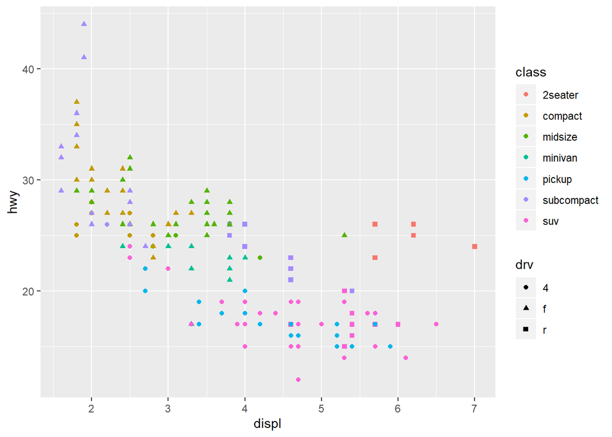

```r
ggplot(mpg, aes(x=displ, y = hwy, shape = drv, color = class)) +
  geom_point()
```

5. Plot the following graph:

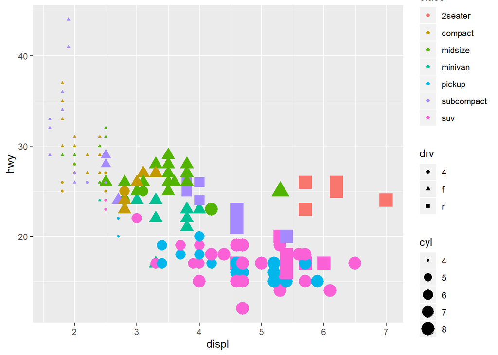

```r
ggplot(mpg, aes(x=displ, y = hwy, shape = drv, color = class, size = cyl)) +
  geom_point()
```

6. How is drive train related to fuel economy? Plot and show

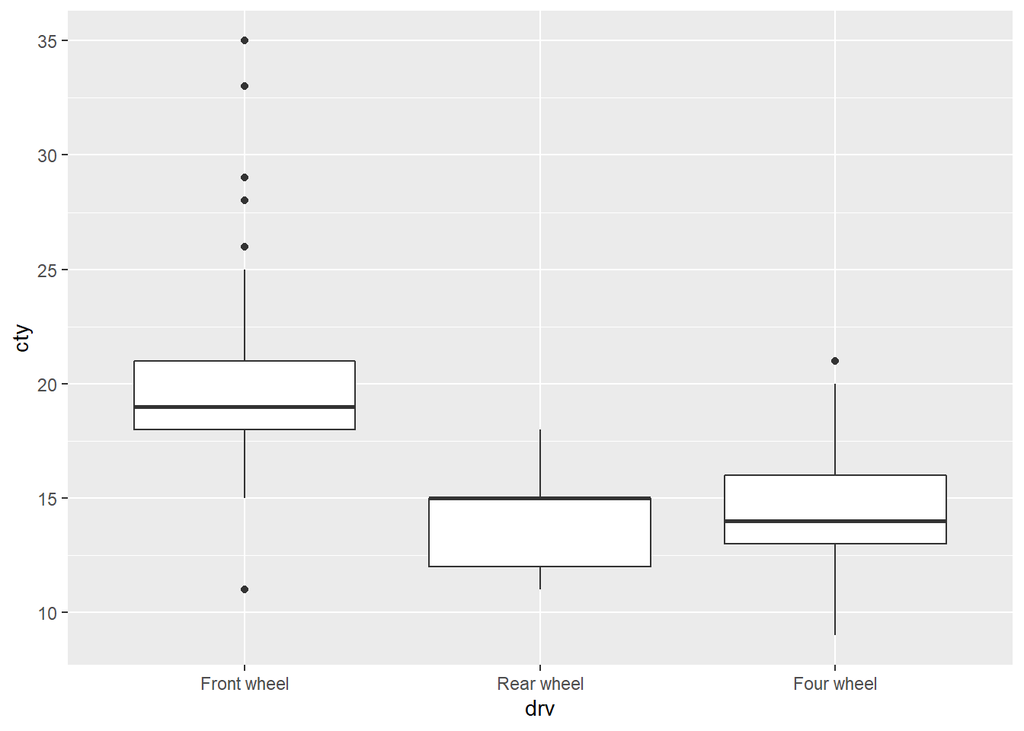

```r
#Fuel economy in CITY
ggplot(mpg, aes(drv, cty)) +
  geom_boxplot() +
  scale_x_discrete(limits = c("f", "r", "4"),
                   labels = c("Front wheel", "Rear wheel", "Four wheel"))
```

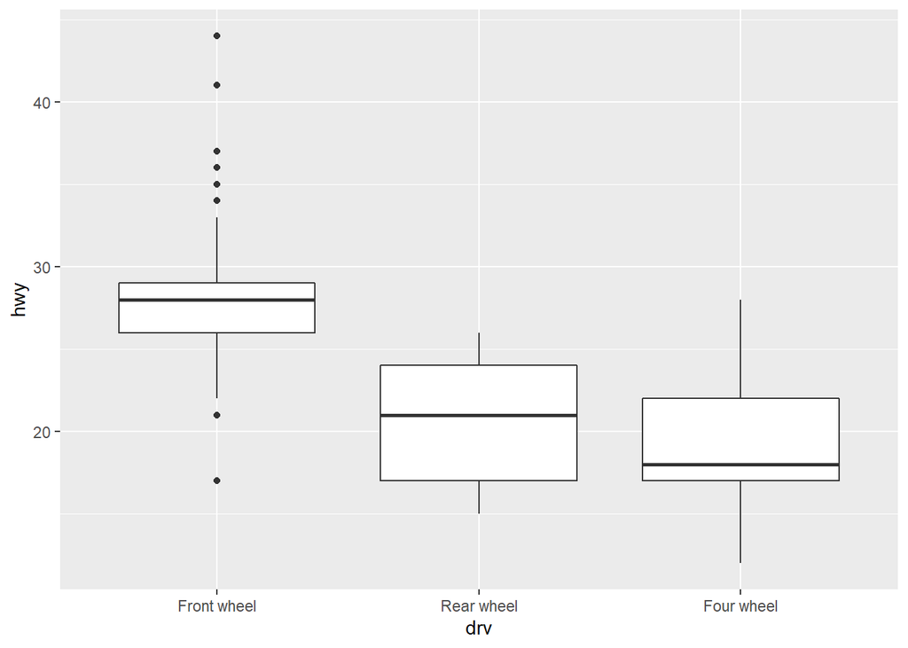

```r
#fuel economy in HIGHWAY
ggplot(mpg, aes(drv, hwy)) +
  geom_boxplot() +
  scale_x_discrete(limits = c("f", "r", "4"),
                   labels = c("Front wheel", "Rear wheel", "Four wheel"))
```

Answer:

Front wheeler vehicles are more fuel efficient for both highway and City drives.

7. How is drive train related to engine size and class? Plot and show

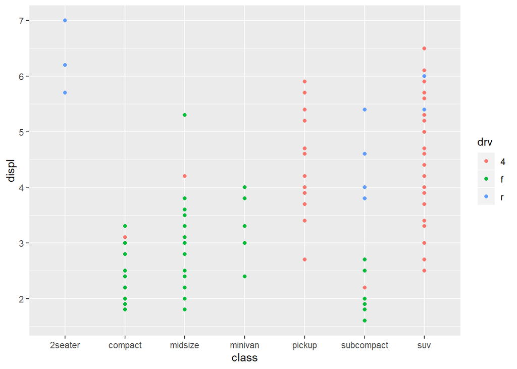

```r
ggplot(mpg, aes(class, displ, color = drv)) + geom_point()
```

Answer: - From the above plot we can say that cars of class ‘suv’, pickup have large engine size and most of them are four wheel drive. - Cars of Class ‘compact’, ‘subcompact’, ‘midsize’, and ‘minivan’ have comparetively less engine size and most of them are front wheel drive. - ‘Two seater’ cars have large engine size than any other and all of them are rear wheel drive.

8. What happens if you map trans variable to shape? Why?

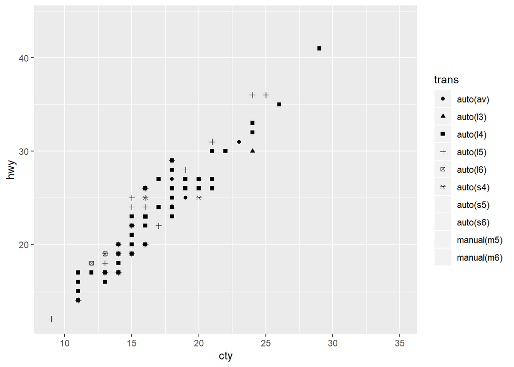

```r
ggplot(mpg, aes(cty, hwy, shape = trans)) +
  geom_point()
```

Answer: The shape palette can deal with a maximum of 6 discrete values because more than 6 becomes difficult to discriminate; you have 10. Consider specifying shapes manually if you must have them. Removed 96 rows containing missing values (geom_point). Hence loss of our data.